# Pivoting Data: Long vs Wide Format

Author

Ceolla Dillon-O’Rourke c.dillonorourke1@universityofgalway.ie

This tutorial should help you:

- understand the difference between long and wide format
- understand why both formats can be useful for data analysis
- understand how to use the functions `pivot_longer()` and `pivot_wider()` from the **tidyverse** package in R

## What’s the difference between Wide Format and Long Format?

**Wide Format**

**One row = One subject**

**Different variable/timepoints = seperate columns**

| Subject | Age | Height | Weight |
| --- | --- | --- | --- |
| 1 | 18 | 160.1 | 54.5 |
| 2 | 22 | 187 | 75.4 |
| 3 | 20 | 164.3 | 62 |
| 4 | 24 | 153.9 | 51.7 |
| 5 | 21 | 172 | 74.3 |

**Long Format**

**One row = One observation**

**Values are stacked into a single column, with a variable type column**

| Subject | Variable | Value |
| --- | --- | --- |
| 1 | Age | 18 |
| 1 | Height | 160.1 |
| 1 | Weight | 54.5 |
| 2 | Age | 22 |
| 2 | Height | 187 |
| 2 | Weight | 75.4 |
| 3 | Age | 20 |
| 3 | Height | 164.3 |
| 3 | Weight | 62 |

## Why would we need both?

| Wide Format | Long Format |
| --- | --- |
| Descriptive Statistics | Visualisation (ggplot, faceting, etc.) |
| Paired Tests (Wilcoxon, t-test) | Mixed Models / Repeated Measures ANOVA |
|  | Grouped Summaries (by measure, timepoint etc.) |

## How to use: pivot_longer() and pivot_wider()

In order to use the functions `pivot_longer()` and `pivot_wider()` , you must download the R package `tidyverse`

```r
library(tidyverse)
```

### Using pivot_longer()

To pivot wide format data to long format

```r
pivot_longer(
  data = ,       # your dataset
  cols = ,       # columns to be pivoted
  names_to = ,   # new column name for old column headers
  values_to =    # new column name for values that were in the old cells
)
```

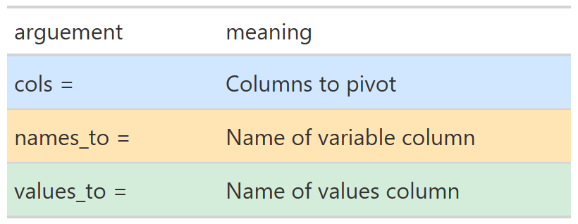

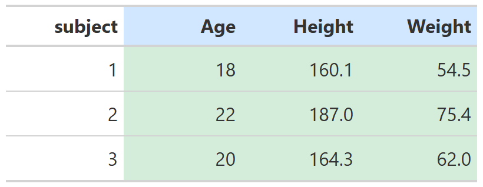

Wide Format

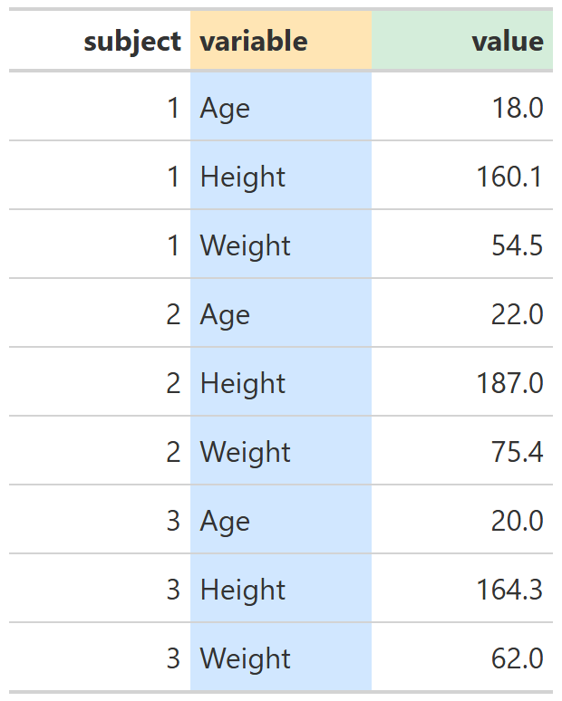

Long Format

### Using pivot_wider()

To pivot long format data to wide format

```r
pivot_wider(
  data = ,        # your dataset
  id_cols = ,     # column(s) that uniquely identify each row
  names_from = ,  # column whose varaibles you want to turn into new column headers
  values_from =   # column that contains the values
)
```

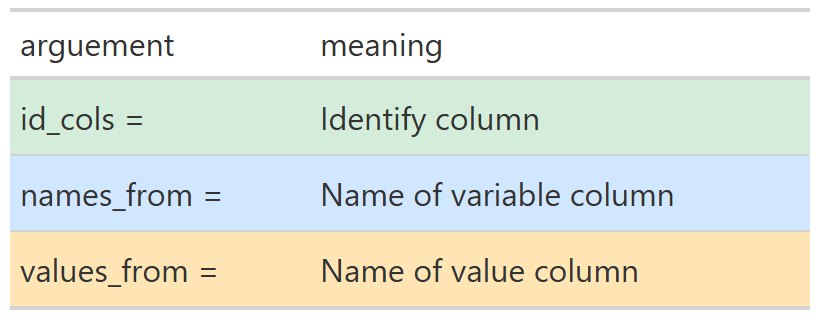

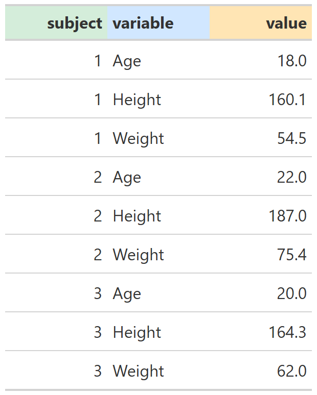

Long Format

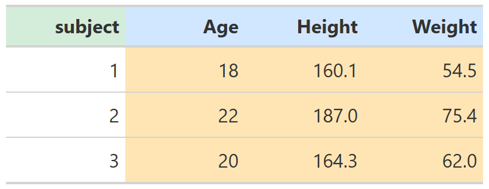

Wide Format

## Complete R script (including video tutorial)

In this tutorial, you’ll learn how to reshape data in R using the `pivot_longer()` and `pivot_wider()` functions from the **tidyverse** package. A short video tutorial and sample datasets are provided so you can work through each step yourself and apply the concepts to your own data.

Watch the video tutorial here

Download the task_data.xlsx file

Download the task_time_data.xlsx file

```r
# -------------------------------------------------------------------------
# Script: tutorial.R
# Author: Ceolla Dillon O'Rourke
# Purpose: Demonstrate how to reshape data using
#          pivot_longer() and pivot_wider() from the tidyr package
# -------------------------------------------------------------------------

# Step 1: Load tidyr package and others
library(tidyverse)
library(readxl)

# Step 2: Set working directory (where your data is located)
setwd("")

# Step 3: Load your data
data <- read_xlsx("task_data.xlsx")

# Step 4: View data

# It's important to understand your dataset before reshaping:
# - Which columns contain repeated measures / variables?
# - Which columns are identifiers? e.g. subject, treatment group, gender

head(data) # this will show you the first 10 rows of your data
View(data) # this will create a tab in R to view the complete data set


# Step 5: Pivot Long

data_long <-
  pivot_longer(
    # your data
    data = data,

    # list what columns you want to pivot (these already exist)
    cols = ends_with("errors"),

    # name of new column header of variables (this is new)
    names_to = "task",

    # name of new column header of values of variables (this is new)
    values_to = "score"
  )

head(data_long)
View(data_long)


# Step 6: Pivot Wide

data_wide <-
  pivot_wider(

    # your long-format dataset
    data = data_long,

    # name column that identifies the subjects (this already exists)
    id_cols = subject,

    # name of column whose values become new column names (this already exist)
    names_from = task,

    # name of column header that contains the values (this already exists)
    values_from = score
  )


# Bonus : Multiple measures by multiple timepoints

bonus <- read_xlsx("task_time_data.xlsx")


bonus_long <-
  pivot_longer(
    # your data
    data = bonus,

    # list what columns you want to pivot (these already exist)
    cols = gonogo_T1:wcst_T2,

    # name of new column header of variables (this is new)
    names_to = c("task", "timepoint"),

    # specify what "task" and "timepoint" are separated by
    names_sep = "_",

    # name of new column header of values of variables (this is new)
    values_to = "score"
  )
```